# Assignment_2RMD

Swapnil Chaudhari (stdid: 10505342)

18 December 2018

### Question 1: [10 Marks]

1. Load the MASS library, and access the dataset quine [1 mark]

```r
library(MASS)
data(quine)
str(quine)
```

```
## 'data.frame':    146 obs. of  5 variables:
##  $ Eth : Factor w/ 2 levels "A","N": 1 1 1 1 1 1 1 1 1 1 ...
##  $ Sex : Factor w/ 2 levels "F","M": 2 2 2 2 2 2 2 2 2 2 ...
##  $ Age : Factor w/ 4 levels "F0","F1","F2",..: 1 1 1 1 1 1 1 1 2 2 ...
##  $ Lrn : Factor w/ 2 levels "AL","SL": 2 2 2 1 1 1 1 1 2 2 ...
##  $ Days: int  2 11 14 5 5 13 20 22 6 6 ...
```

2. A researcher is interested in seeing if the number of days in which students were absent differs between Aboriginal and non-Aboriginal students. In order to do this, she creates the plot below, showing two histograms on the same panel. Your task is to reproduce this plot. (You can be creative and make the histograms look different if you like - but the information it displays must obviously be the same.)[7 marks]

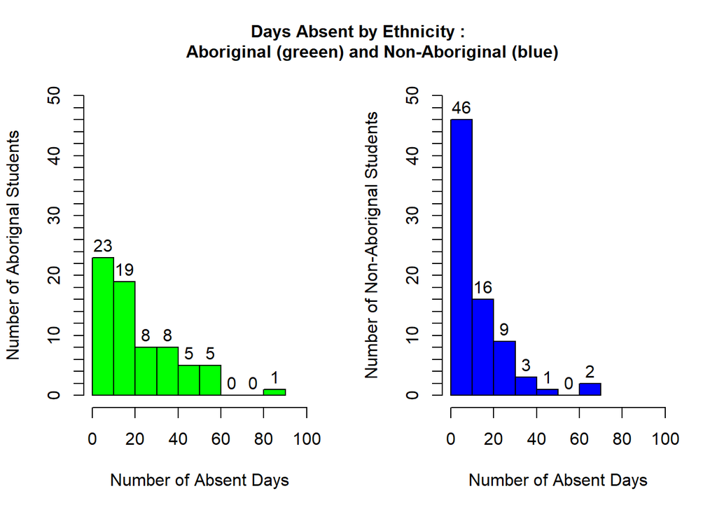

```r
#create panel of one row two col
par(mfrow = c(1, 2))

# And  use histogram for aborignal:
hist(quine$Days[quine$Eth=='A'],
     xlab = "Number of Absent Days",
     xlim = c(0,100),
     ylim = c(0,50),
     ylab="Number of Aborignal Students",
     labels = TRUE,
     main = "",

     col = "green")
axis(side = 2, at = seq(0, 50, by = 2), labels = F)
# create second histo gramfor non-aboriginal
hist(quine$Days[quine$Eth=='N'],
     xlab = "Number of Absent Days",
     main="",
     labels = TRUE,
     ylab="Number of Non-Aborignal Students",
     xlim = c(0,100),
     ylim = c(0,50),
     col = "blue")
axis(side = 2, at = seq(0, 50, by = 2), labels = F)

mtext("Days Absent by Ethnicity :
      Aboriginal (greeen) and Non-Aboriginal (blue)", side = 3, line = -3, font = 2, outer = T , padj = 0 )
```

```r
#tally results by code
# data=quine[ which (quine$Eth=='A'& quine$Days<=10),]
# nrow(data)
```

3. Comment on whether you think there is any evidence of a difference between the two groups. [2 marks]

### Question 2: [10 marks]

1. Load the MASS library, and access the dataset crabs. Look at its structure (you may also need to load the help file to read about the dataset) [1 marks]

```r
library("MASS")
data(crabs)
```

2. A marine biologist is interested in seeing what relationship the categorical variables of sex and species have with the numerical variable measuring the rear width of the crabs. He produces the plot below. Your task is to reproduce this plot. (You can be creative and make the graph look different if you like - but the information it displays must obviously be the same.) [7 marks]

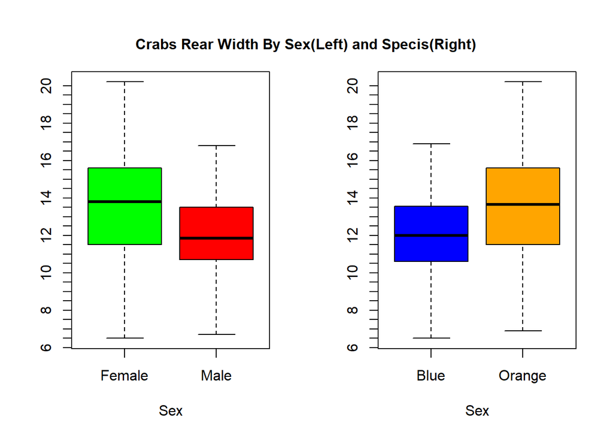

```r
par(mfrow = c(1,2))

# create box plot for sex group vs. rear width
boxplot(crabs$RW ~ crabs$sex,
        xlab = "Sex",
        col = c("green","red"),
        names= c("Female","Male"),
        main = "",

        )
axis(side = 2, at = seq(0, 20, by = 0.5), labels = F)

# create box plot for species vs. rear width
boxplot(crabs$RW ~ crabs$sp,
        xlab = "Sex",
        col = c("blue", "Orange"),
        names = c("Blue", "Orange"),
        main = "",
        )
axis(side = 2, at = seq(0, 20, by = 0.5), labels = F)
mtext("Crabs Rear Width By Sex(Left) and Specis(Right)",side = 3, line = -3, font = 2, outer = T , padj = 0 )
```

3. Comment on the resulting plots - what can the marine biologist say about the rear width of the crabs? [2 marks]

Marine biologist can conclude that female crabs have wider and more varying rear width as compare to their male crabs. Similarly, orange species have more wider and varying rear than that of blue species. Overall,they can conclude that majority of orange female species have the widest and the most varying rear.

### Question 3: [10 marks]

1. Set x to be 2, y to be 3 and z to be 4. Write a while() loop which prints x + y + z and then doubles both x and y and adds 1 to z. The loop should stop only when x is greater than 50, or y is greater than 70, or z is greater than 10. What is the final value printed to the console? [3 marks]

```r
x<-2
y<-3
z<-4

while( x<50 | y<70 | z<10)
{
  x<- 2 * x
  y<- 2 * y
  z<- z +1
  print(x+y+z)
}
```

```
## [1] 15
## [1] 26
## [1] 47
## [1] 88
## [1] 169
## [1] 330
```

The final value printed on the console is 330.

2. Create a matrix of size 10 x 6. Write a double for() loop which fills this matrix with values equal to the sin of the row index times the cosine of the column index. e.g., the [1, 1] entry should be sin(1)xcos(1), the [3, 4] entry should be sin(3)xcos(4) etc. Print the matrix. [4 marks]

```r
m <- matrix(nrow = 10, ncol =  6)
for(i in 1:10)
{
  for(j in 1:6)
  {
    m[i,j]<- sin(i) * cos(j)
  }
}
print(m)
```

```
##              [,1]        [,2]       [,3]        [,4]        [,5]
##  [1,]  0.45464871 -0.35017549 -0.8330500 -0.55002214  0.23869350
##  [2,]  0.49129550 -0.37840125 -0.9001976 -0.59435646  0.25793330
##  [3,]  0.07624747 -0.05872664 -0.1397077 -0.09224219  0.04003041
##  [4,] -0.40890213  0.31494096  0.7492288  0.49467912 -0.21467625
##  [5,] -0.51810900  0.39905330  0.9493278  0.62679474 -0.27201056
##  [6,] -0.15096884  0.11627788  0.2766192  0.18263816 -0.07925961
##  [7,]  0.35497137 -0.27340289 -0.6504118 -0.42943510  0.18636225
##  [8,]  0.53455254 -0.41171830 -0.9794572 -0.64668771  0.28064352
##  [9,]  0.22266857 -0.17150180 -0.4079942 -0.26937862  0.11690243
## [10,] -0.29393586  0.22639266  0.5385768  0.35559593 -0.15431822
##             [,6]
##  [1,]  0.8079554
##  [2,]  0.8730804
##  [3,]  0.1354992
##  [4,] -0.7266593
##  [5,] -0.9207306
##  [6,] -0.2682865
##  [7,]  0.6308190
##  [8,]  0.9499524
##  [9,]  0.3957039
## [10,] -0.5223529
```

3. Set i to be 2. Write a repeat() loop which trebles i until i is greater than 200. What value is i now? [3 marks]

```r
i<- 2
repeat
{
  ifelse(i>200, break, i<- i*3  )


}
print(i)
```

```
## [1] 486
```

Value of i is now 486.

### Question 4: [30 Marks]

Download the file imdb.txt which contains the html webpage output of the IMDB top 250 flms). Scan this in, and then answer the following questions:

1. In how many of the top 250 films does the actress Grace Kelly appear? [5 marks]

```r
imdb= scan("F:/DBS/R programming/imdb.txt" ,what = 'character',sep='\n')

# grep() finds the specified pattern in x
indexes =grep("Grace Kelly" ,imdb)
count=length(indexes)

paste("Actor Grace Kelly appears in ", count," films in top 250 imdb movies.")
```

```
## [1] "Actor Grace Kelly appears in  2  films in top 250 imdb movies."
```

2. What are the names of the films in which she appears? [5 marks]

```r
filmdetails =imdb[indexes]

filmnameRegex="^title=.* >"

#replacing title= ... to > part with null'
films <- gsub( filmnameRegex,"",filmdetails)
films <- gsub("</a> $",",",films)
films
```

```
## [1] "Rear Window,"       "Dial M for Murder,"
```

```r
cat("Actor Grace Kelly appears in ", count," times in top 250 imdb movies. her films are ",films )
```

```
## Actor Grace Kelly appears in  2  times in top 250 imdb movies. her films are  Rear Window, Dial M for Murder,
```

3. In how many of the top 250 films does the director have B as the first initial of their first name? Are any of these directors included more than once in the list? (As always, you need to use code to answer all parts of this - not just read the answer from a table etc.)

```r
#getting lines starting with 'title=\"B' and contains '(dir.)' in between

dataDirectorsB = imdb[grep('^title=\"B.*\\(dir\\.\\)',imdb)]
dataDirectorsB
```

```
##  [1] "title=\"Bryan Singer (dir.), Kevin Spacey, Gabriel Byrne\" >The Usual Suspects</a> "
##  [2] "title=\"Billy Wilder (dir.), William Holden, Gloria Swanson\" >Sunset Blvd.</a> "
##  [3] "title=\"Billy Wilder (dir.), Tyrone Power, Marlene Dietrich\" >Witness for the Prosecution</a> "
##  [4] "title=\"Billy Wilder (dir.), Fred MacMurray, Barbara Stanwyck\" >Double Indemnity</a> "
##  [5] "title=\"Brian De Palma (dir.), Al Pacino, Michelle Pfeiffer\" >Scarface</a> "
##  [6] "title=\"Billy Wilder (dir.), Jack Lemmon, Shirley MacLaine\" >The Apartment</a> "
##  [7] "title=\"Billy Wilder (dir.), Marilyn Monroe, Tony Curtis\" >Some Like It Hot</a> "
##  [8] "title=\"Bryan Singer (dir.), Rami Malek, Lucy Boynton\" >Bohemian Rhapsody</a> "
##  [9] "title=\"Buster Keaton (dir.), Buster Keaton, Kathryn McGuire\" >Sherlock Jr.</a> "
## [10] "title=\"Bradley Cooper (dir.), Lady Gaga, Bradley Cooper\" >A Star Is Born</a> "
```

```r
paste("In total ",length(dataDirectorsB)," films the director have B as the first initial of their first name")
```

```
## [1] "In total  10  films the director have B as the first initial of their first name"
```

In total 10 films of top imdb 250 movies directors have first name starting with B.

Are any of these directors included more than once in the list?

```r
#replacing 'title=\"' with null
a= gsub('^title=\"',"",dataDirectorsB)
a
```

```
##  [1] "Bryan Singer (dir.), Kevin Spacey, Gabriel Byrne\" >The Usual Suspects</a> "
##  [2] "Billy Wilder (dir.), William Holden, Gloria Swanson\" >Sunset Blvd.</a> "
##  [3] "Billy Wilder (dir.), Tyrone Power, Marlene Dietrich\" >Witness for the Prosecution</a> "
##  [4] "Billy Wilder (dir.), Fred MacMurray, Barbara Stanwyck\" >Double Indemnity</a> "
##  [5] "Brian De Palma (dir.), Al Pacino, Michelle Pfeiffer\" >Scarface</a> "
##  [6] "Billy Wilder (dir.), Jack Lemmon, Shirley MacLaine\" >The Apartment</a> "
##  [7] "Billy Wilder (dir.), Marilyn Monroe, Tony Curtis\" >Some Like It Hot</a> "
##  [8] "Bryan Singer (dir.), Rami Malek, Lucy Boynton\" >Bohemian Rhapsody</a> "
##  [9] "Buster Keaton (dir.), Buster Keaton, Kathryn McGuire\" >Sherlock Jr.</a> "
## [10] "Bradley Cooper (dir.), Lady Gaga, Bradley Cooper\" >A Star Is Born</a> "
```

```r
#replacing part (\\dir to end of string with null
directornamesB=gsub('\\(dir\\..*</a> ',"",a)
directornamesB
```

```
##  [1] "Bryan Singer "   "Billy Wilder "   "Billy Wilder "
##  [4] "Billy Wilder "   "Brian De Palma " "Billy Wilder "
##  [7] "Billy Wilder "   "Bryan Singer "   "Buster Keaton "
## [10] "Bradley Cooper "
```

```r
#removing last space
directornamesB=gsub(" $","",directornamesB)
directornamesB
```

```
##  [1] "Bryan Singer"   "Billy Wilder"   "Billy Wilder"   "Billy Wilder"
##  [5] "Brian De Palma" "Billy Wilder"   "Billy Wilder"   "Bryan Singer"
##  [9] "Buster Keaton"  "Bradley Cooper"
```

displaying duplicate entries

```r
tDuplicateCounts= as.data.frame((table(directornamesB)))
colnames(tDuplicateCounts) <- c("DirectorName","CountDuplicate")
tDuplicateCounts
```

```
##     DirectorName CountDuplicate
## 1   Billy Wilder              5
## 2 Bradley Cooper              1
## 3 Brian De Palma              1
## 4   Bryan Singer              2
## 5  Buster Keaton              1
```

```r
cat(toString(unique(directornamesB))," appears ", toString(tDuplicateCounts$CountDuplicate)," times respectively.")
```

[output not shown]

4. How many of the top 250 films have `A’ as the first word in their title? [5 marks]

getting lines only related to film which contains (dir.)

```r
filmnameRegex="^title=.*\\(dir\\..*</a>"
films = imdb[grep(filmnameRegex ,imdb)]

films <- gsub( "^title=.* >","",films)
films <- gsub("</a> $",",",films)
films <- films[grep("^A",films)]
```

films with first letter A in title:

```r
films
```

```
##  [1] "American History X,"     "Apocalypse Now,"
##  [3] "Alien,"                  "Avengers: Infinity War,"
##  [5] "American Beauty,"        "Aliens,"
##  [7] "Amadeus,"                "A Clockwork Orange,"
##  [9] "AmÃ©lie,"                "All About Eve,"
## [11] "A Beautiful Mind,"       "A Star Is Born,"
## [13] "Andrei Rublev,"          "Amores perros,"
## [15] "Ah-ga-ssi,"
```

```r
cat("Total ",length(films)," films have starting letter of title is A. ")
```

```
## Total  15  films have starting letter of title is A.
```

22. How many of the top 250 films have a score greater than 8 and less than 8.4? [5 marks]

extracting lines (**8.4** ) related each movie ratings and getting rating points.

```r
# <strong title="8.4 based on 528,467 user ratings">8.4</strong>
ratingsRegex= ' <strong title='
ratings = imdb[grep(ratingsRegex,imdb)]
ratings
```

```
##   [1] "            <strong title=\"9.2 based on 2,015,941 user ratings\">9.2</strong> "
##   [2] "            <strong title=\"9.2 based on 1,381,295 user ratings\">9.2</strong> "
##   [3] "            <strong title=\"9.0 based on 956,502 user ratings\">9.0</strong> "
##   [4] "            <strong title=\"9.0 based on 1,984,242 user ratings\">9.0</strong> "
##   [5] "            <strong title=\"8.9 based on 565,283 user ratings\">8.9</strong> "
##   [6] "            <strong title=\"8.9 based on 1,040,610 user ratings\">8.9</strong> "
##   [7] "            <strong title=\"8.9 based on 1,434,854 user ratings\">8.9</strong> "
##   [8] "            <strong title=\"8.9 based on 1,573,618 user ratings\">8.9</strong> "
##   [9] "            <strong title=\"8.8 based on 597,431 user ratings\">8.8</strong> "
##  [10] "            <strong title=\"8.8 based on 1,612,797 user ratings\">8.8</strong> "
##  [11] "            <strong title=\"8.8 based on 1,451,475 user ratings\">8.8</strong> "
##  [12] "            <strong title=\"8.7 based on 1,535,951 user ratings\">8.7</strong> "
##  [13] "            <strong title=\"8.7 based on 1,012,174 user ratings\">8.7</strong> "
##  [14] "            <strong title=\"8.7 based on 1,764,083 user ratings\">8.7</strong> "
##  [15] "            <strong title=\"8.7 based on 1,297,052 user ratings\">8.7</strong> "
```

[output cut: 235 more lines]

```r
ratings= gsub('.*">',"",ratings)
ratings=gsub("</strong> $","",ratings)
```

convert string to double

```r
#
ratings = as.double(ratings)

ratings
```

```
##   [1] 9.2 9.2 9.0 9.0 8.9 8.9 8.9 8.9 8.8 8.8 8.8 8.7 8.7 8.7 8.7 8.7 8.7
##  [18] 8.6 8.6 8.6 8.6 8.6 8.6 8.6 8.6 8.5 8.5 8.5 8.5 8.5 8.5 8.5 8.5 8.5
##  [35] 8.5 8.5 8.5 8.5 8.5 8.5 8.5 8.5 8.5 8.5 8.5 8.5 8.5 8.5 8.4 8.4 8.4
##  [52] 8.4 8.4 8.4 8.4 8.4 8.4 8.4 8.4 8.4 8.4 8.4 8.4 8.4 8.4 8.4 8.3 8.3
##  [69] 8.3 8.3 8.3 8.3 8.3 8.3 8.3 8.3 8.3 8.3 8.3 8.3 8.3 8.3 8.3 8.3 8.3
##  [86] 8.3 8.3 8.3 8.3 8.3 8.3 8.3 8.3 8.3 8.3 8.3 8.3 8.3 8.3 8.3 8.3 8.3
## [103] 8.3 8.2 8.2 8.2 8.2 8.2 8.2 8.2 8.2 8.2 8.2 8.2 8.2 8.2 8.2 8.2 8.2
## [120] 8.2 8.2 8.2 8.2 8.2 8.2 8.2 8.2 8.2 8.2 8.2 8.2 8.2 8.2 8.2 8.2 8.2
## [137] 8.2 8.2 8.2 8.2 8.2 8.2 8.2 8.2 8.2 8.1 8.1 8.1 8.1 8.1 8.1 8.1 8.1
## [154] 8.1 8.1 8.1 8.1 8.1 8.1 8.1 8.1 8.1 8.1 8.1 8.1 8.1 8.1 8.1 8.1 8.1
## [171] 8.1 8.1 8.1 8.1 8.1 8.1 8.1 8.1 8.1 8.1 8.1 8.1 8.1 8.1 8.1 8.1 8.1
## [188] 8.1 8.1 8.1 8.1 8.1 8.1 8.1 8.1 8.1 8.1 8.1 8.1 8.1 8.1 8.1 8.1 8.1
## [205] 8.1 8.1 8.1 8.1 8.1 8.1 8.1 8.1 8.1 8.0 8.0 8.0 8.0 8.0 8.0 8.0 8.0
## [222] 8.0 8.0 8.0 8.0 8.0 8.0 8.0 8.0 8.0 8.0 8.0 8.0 8.0 8.0 8.0 8.0 8.0
## [239] 8.0 8.0 8.0 8.0 8.0 8.0 8.0 8.0 8.0 8.0 8.0 8.0
```

counting total films with ratings>8.0 & ratings<8.4

```r
count = sum(ratings>8.0 & ratings<8.4)
```

displaying result:

```r
cat(count ," of top 250 movies have ratings > 8.0 and <8.4 ")
```

```
## 147  of top 250 movies have ratings > 8.0 and <8.4
```

6. User ratings are used to define the top 250 films. What is the average number of user ratings for the 250 films? [5 marks]

```r
mean(ratings)
```

```
## [1] 8.2576
```

```r
userratingRegex=".*based on "
userratings = imdb[grep(ratingsRegex,imdb)]

#replacing portion from beginning to just before user numbers with null
userratings= gsub(userratingRegex,"",userratings)

#replacing the string portion after numer of users
userratings=gsub(" user ratings.*</strong> $","",userratings)

#replacing , with ""
userratings=gsub(",","",userratings)

#converting string array to double
users= as.double(userratings)

mean(users)
```

```
## [1] 477186.7
```

```r
paste0("Average number of user rated  for each top 250 imdb films are ", round(mean(users),0))
```

```
## [1] "Average number of user rated  for each top 250 imdb films are 477187"
```